# Проектная работа. Образование планетной системы

Второй этап

Арбатова Варвара Петровна

1132236020@rudn.ru

Российский университет дружбы народов

Карпова Есения Алексеевна

1132236008@rudn.ru

Российский университет дружбы народов

Дагделен Зейнап Реджеповна

1132236052@rudn.ru

Российский университет дружбы народов

Бюгданюк Анна Васильевна

1132236023@rudn.ru

Российский университет дружбы народов

Люпп Софья Романовна

1132236039@rudn.ru

Российский университет дружбы народов

2026-04-11

# Цель работы

Разработать алгоритмы численного моделирования формирования планетной системы из газопылевого облака для последующей реализации программы.

# Блок-схема (главный цикл)

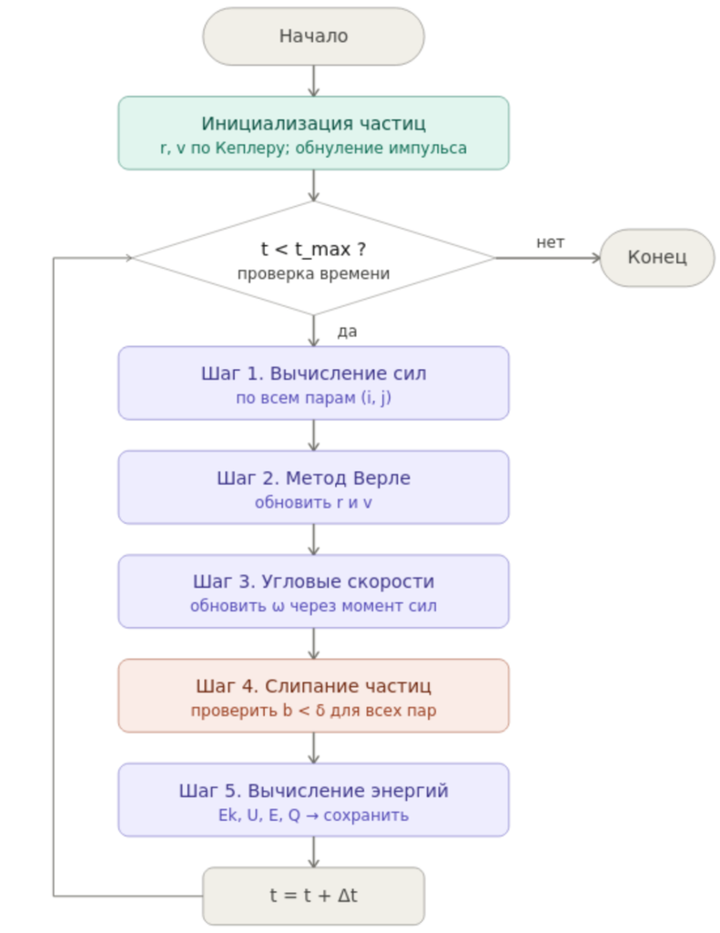

Рисунок 1

Рассмотрим каждый шаг поподробнее

## Структуры данных

- Каждая частица описывается набором параметров. Все частицы хранятся в массиве длины $N$. Активные частицы участвуют в расчётах, неактивные — игнорируются (после слипания)

[figure not shown]

Рисунок 2

## Инициализация

- Частицы распределены в диске:

$$r = r_0\sqrt{\xi_1}, \quad \alpha = 2\pi\,\xi_2$$

- Начальные скорости — кеплеровские:

$$v_x = -y\,\omega_0\left(\frac{r_0}{r}\right)^{3/2}, \quad v_y = x\,\omega_0\left(\frac{r_0}{r}\right)^{3/2}, \quad v_z = 0$$

- Обнуление центра масс (коррекция суммарного импульса).

## Шаг 1. Вычисление сил. Гравитация и отталкивание

- Гравитация:

$$\mathbf{F}^g_{ij} = -\frac{\gamma m_i m_j}{b^3}\,\mathbf{b}_{ij}$$

- Отталкивание (при столкновении/сжатии): растёт с уменьшением расстояния
- Итоговая сила: векторная сумма по всем парам частиц

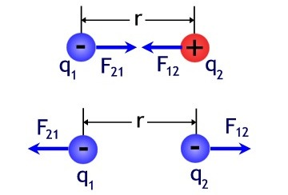

Рисунок 3

## Шаг 1. Вычисление сил. Сила трения (касательная)

- Зависит от относительной скорости поверхностей
- Учитывает вращение частиц ($\omega_i R_i$ — скорость поверхности)
- Направлена по касательной к контакту

## Шаг 2. Интегрирование уравнений движения (метод Верле)

- Предиктор (положение):

$$\mathbf{r}_i \leftarrow \mathbf{r}_i + \mathbf{v}_i\,\Delta t + \frac{\mathbf{F}_i}{2m_i}\,\Delta t^2$$

- Корректор (скорость):

$$\mathbf{v}_i \leftarrow \mathbf{v}_i + \frac{\mathbf{F}_i^{\,\text{old}} + \mathbf{F}_i^{\,\text{new}}}{2m_i}\,\Delta t$$

## Шаг 3. Обновление угловых скоростей

- Момент инерции сферы:

$$I_i = \frac{2}{5}m_i R_i^2$$

- Угловое ускорение от касательных сил трения:

$$\varepsilon_i = \frac{1}{I_i}\sum_{j} \frac{b_{ij}}{R_i + R_j} F^f_{ij}$$

- Обновление:

$$\omega_i \leftarrow \omega_i + \varepsilon_i\,\Delta t$$

## Шаг 4. Проверка условия слипания

**Условие:** расстояние $b_{ij} < \delta$ (порог)

**Сохранение:**

- Масса: $m = m_i + m_j$
- Импульс: $\mathbf{v} = (m_i\mathbf{v}_i + m_j\mathbf{v}_j)/m$
- Радиус: $R = \sqrt[3]{R_i^3 + R_j^3}$

Результат на место $i$, частица $j$ — неактивна

## Шаг 5. Вычисление и запись энергий

- **Кинетическая:**

$$E_k = \sum_i \frac{m_i v_i^2}{2} + \sum_i \frac{I_i \omega_i^2}{2}$$

- **Потенциальная:**

$$U = -\frac{1}{2}\sum_{i \neq j} \frac{\gamma m_i m_j}{b_{ij}}$$

- **Полная энергия и диссипация:**

$$E = E_k + U, \quad Q(t) = E(0) - E(t)$$

# Вывод

На этапе разработаны алгоритмы моделирования: инициализация частиц, расчёт сил, интегрирование Верле, обновление угловых скоростей, слипание частиц, вычисление энергий. Полученные алгоритмы — основа для программной реализации.